# Project Python Foundations: FoodHub Data Analysis

Project Created by: Bindu Kaimal

**Marks: 60**

### Context

The number of restaurants in New York is increasing day by day. Lots of students and busy professionals rely on those restaurants due to their hectic lifestyles. Online food delivery service is a great option for them. It provides them with good food from their favorite restaurants. A food aggregator company FoodHub offers access to multiple restaurants through a single smartphone app.

The app allows the restaurants to receive a direct online order from a customer. The app assigns a delivery person from the company to pick up the order after it is confirmed by the restaurant. The delivery person then uses the map to reach the restaurant and waits for the food package. Once the food package is handed over to the delivery person, he/she confirms the pick-up in the app and travels to the customer's location to deliver the food. The delivery person confirms the drop-off in the app after delivering the food package to the customer. The customer can rate the order in the app. The food aggregator earns money by collecting a fixed margin of the delivery order from the restaurants.

### Objective

The food aggregator company has stored the data of the different orders made by the registered customers in their online portal. They want to analyze the data to get a fair idea about the demand of different restaurants which will help them in enhancing their customer experience. Suppose you are hired as a Data Scientist in this company and the Data Science team has shared some of the key questions that need to be answered. Perform the data analysis to find answers to these questions that will help the company to improve the business.

### Data Description

The data contains the different data related to a food order. The detailed data dictionary is given below.

### Data Dictionary

- order_id: Unique ID of the order
- customer_id: ID of the customer who ordered the food
- restaurant_name: Name of the restaurant
- cuisine_type: Cuisine ordered by the customer
- cost: Cost of the order
- day_of_the_week: Indicates whether the order is placed on a weekday or weekend (The weekday is from Monday to Friday and the weekend is Saturday and Sunday)
- rating: Rating given by the customer out of 5
- food_preparation_time: Time (in minutes) taken by the restaurant to prepare the food. This is calculated by taking the difference between the timestamps of the restaurant's order confirmation and the delivery person's pick-up confirmation.
- delivery_time: Time (in minutes) taken by the delivery person to deliver the food package. This is calculated by taking the difference between the timestamps of the delivery person's pick-up confirmation and drop-off information

# **Course 1 Project: Food Hub**

### Let us start by importing the required libraries

```python
# import libraries for data manipulation
import numpy as np
import pandas as pd

# import libraries for data visualization
import matplotlib.pyplot as plt
import seaborn as sns
%matplotlib inline
pd.set_option('display.float_format', lambda x: '%.2f' % x)
```

### Understanding the structure of the data

```python
from google.colab import drive
drive.mount('/content/drive')
```

```python
# read the data
data = pd.read_csv('foodhub_order.csv')
# copying data to another variable to avoid any changes to original data
df = data.copy()
# returns the first 5 rows
df.head()
```

|  | order_id | customer_id | restaurant_name | cuisine_type | cost_of_the_order | day_of_the_week | rating | food_preparation_time | delivery_time |
| --- | --- | --- | --- | --- | --- | --- | --- | --- | --- |
| 0 | 1477147 | 337525 | Hangawi | Korean | 30.75 | Weekend | Not given | 25 | 20 |
| 1 | 1477685 | 358141 | Blue Ribbon Sushi Izakaya | Japanese | 12.08 | Weekend | Not given | 25 | 23 |
| 2 | 1477070 | 66393 | Cafe Habana | Mexican | 12.23 | Weekday | 5 | 23 | 28 |
| 3 | 1477334 | 106968 | Blue Ribbon Fried Chicken | American | 29.20 | Weekend | 3 | 25 | 15 |
| 4 | 1478249 | 76942 | Dirty Bird to Go | American | 11.59 | Weekday | 4 | 25 | 24 |

#### Observations:

The DataFrame has 9 columns as mentioned in the Data Dictionary.

Data in each row corresponds to the order placed by a customer.

### **Question 1:** How many rows and columns are present in the data? [0.5 mark]

```python
#number of rows and columns in the data
num_rows, num_cols = df.shape
# Print the results
print("Number of rows:", num_rows)
print("Number of columns:", num_cols)
```

```
Number of rows: 1898
Number of columns: 9
```

#### Observations:

The DataFrame has 1898 rows and 9 columns. Reference: [check the number of rows and columns](https://livebook.manning.com/book/data-science-bookcamp/chapter-9/)

### **Question 2:** What are the datatypes of the different columns in the dataset? (The info() function can be used) [0.5 mark]

```python
# Concise summary of the DataFrame
df.info()
```

```
<class 'pandas.core.frame.DataFrame'>
RangeIndex: 1898 entries, 0 to 1897
Data columns (total 9 columns):
 #   Column                 Non-Null Count  Dtype
---  ------                 --------------  -----
 0   order_id               1898 non-null   int64
 1   customer_id            1898 non-null   int64
 2   restaurant_name        1898 non-null   object
 3   cuisine_type           1898 non-null   object
 4   cost_of_the_order      1898 non-null   float64
 5   day_of_the_week        1898 non-null   object
 6   rating                 1898 non-null   object
 7   food_preparation_time  1898 non-null   int64
 8   delivery_time          1898 non-null   int64
dtypes: float64(1), int64(4), object(4)
memory usage: 133.6+ KB
```

#### Observations:

**The summary of a pandas DataFrame object contains 1898 rows and 9 columns**.

1. RangeIndex: 1898 entries, 0 to 1897: This shows the range of the DataFrame's index, which in this case goes from 0 to 1897 and contains a total of 1898 rows.
2. Data columns (total 9 columns): This indicates the number of columns in the DataFrame, which is 9 in this case.
3. Column: This lists the names of each column in the DataFrame.
4. Non-Null Count: This shows the number of non-null values for each column in the DataFrame.
5. Dtype: This shows the data type of each column in the DataFrame.
6. From the output, we can see that the DataFrame contains
7. 4 integer columns (order_id, customer_id, food_preparation_time, and delivery_time),
8. 1 float column (cost_of_the_order), and
9. 4 object columns (restaurant_name, cuisine_type, day_of_the_week, and rating).
10. Additionally, we can see that **there are no missing values** (**Non-Null Count is the same as the total number of rows**)

### **Question 3:** Are there any missing values in the data? If yes, treat them using an appropriate method. [1 mark]

```python
# Check for missing values
missing_values = df.isnull()

# Sum the missing values for each column
missing_values_count = missing_values.sum()

# Print the results
print(missing_values_count)
```

```
order_id                 0
customer_id              0
restaurant_name          0
cuisine_type             0
cost_of_the_order        0
day_of_the_week          0
rating                   0
food_preparation_time    0
delivery_time            0
dtype: int64
```

#### Observations:

There are *no missing values* in any of the 9 columns.

Hence, they will not be treated for missing values. But see text below.

Reference: [Missing Values](https://pandas.pydata.org/docs/reference/api/pandas.DataFrame.isnull.html)

The 'rating' column contains 736 instances of the string value 'Not given', but there are no other missing values in the data. To process this column, I will convert it to a numeric data type, and then I will replace all occurrences of 'Not given' with a numeric value. To do so, I will impute the mean rating value for each restaurant's cuisine type, where the mean rating is computed over all restaurants of the same cuisine type as the one being imputed. For example, if a Chinese cuisine restaurant named 'XYZ' has 'Not given' values, I will compute the mean rating value of all other Chinese cuisine restaurants in the data and fill in this mean value for the 'Not given' values of 'XYZ'.

```python
# create a new DataFrame with a new rating column that contains all numeric values
new_df = df.copy()  # make a copy of the original DataFrame

new_df['rating'] = pd.to_numeric(new_df['rating'], errors='coerce')  # convert 'rating' to numeric

# group the DataFrame by 'cuisine_type' and calculate the mean for each group
mean_by_cuisine = new_df.groupby('cuisine_type')['rating'].mean()

# replace 'Not given' values with mean for corresponding 'cuisine_type'
new_df.loc[new_df['rating'].isna(), 'rating'] = new_df.loc[new_df['rating'].isna(), 'cuisine_type'].map(mean_by_cuisine)

# display the new DataFrame
print(new_df)
```

```
      order_id  customer_id                        restaurant_name  \
0      1477147       337525                                Hangawi
1      1477685       358141              Blue Ribbon Sushi Izakaya
2      1477070        66393                            Cafe Habana
3      1477334       106968              Blue Ribbon Fried Chicken
4      1478249        76942                       Dirty Bird to Go
...        ...          ...                                    ...
1893   1476701       292602  Chipotle Mexican Grill $1.99 Delivery
1894   1477421       397537                              The Smile
1895   1477819        35309                      Blue Ribbon Sushi
1896   1477513        64151                      Jack's Wife Freda
1897   1478056       120353                      Blue Ribbon Sushi

       cuisine_type  cost_of_the_order day_of_the_week  rating  \
0            Korean              30.75         Weekend    4.11
```

[output cut: 25 more lines]

Now using the new dataset, I will create a bar graph.

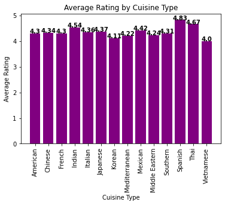

```python
# group the DataFrame by 'cuisine_type' and calculate the mean rating for each group
mean_by_cuisine = new_df.groupby('cuisine_type')['rating'].mean()

# create a bar graph
plt.bar(mean_by_cuisine.index, mean_by_cuisine.values,color='purple')

# add value labels to the top of each bar
for i, v in enumerate(mean_by_cuisine.values):
    plt.text(i, v, str(round(v, 2)), ha='center', fontweight='bold')

# set the title and axis labels
plt.title('Average Rating by Cuisine Type')
plt.xlabel('Cuisine Type')
plt.ylabel('Average Rating')
plt.xticks(rotation=90)
# display the graph
plt.show()
```

After imputing values for the 'Not given' values, we can see that overall Spanish Restaurants, followed by Thai and Indian have higher ratings compared to all other restaurants.

### **Question 4:** Check the statistical summary of the data. What is the minimum, average, and maximum time it takes for food to be prepared once an order is placed? [2 marks]

```python
# Check Statistical Summary of the data
df.describe(include='all').T
#include='all'includes summary statistics for both numeric and non-numeric data
#.T: transposes the resulting summary statistics table.
```

|  | count | unique | top | freq | mean | std | min | 25% | 50% | 75% | max |
| --- | --- | --- | --- | --- | --- | --- | --- | --- | --- | --- | --- |
| order_id | 1898.00 | NaN | NaN | NaN | 1477495.50 | 548.05 | 1476547.00 | 1477021.25 | 1477495.50 | 1477969.75 | 1478444.00 |
| customer_id | 1898.00 | NaN | NaN | NaN | 171168.48 | 113698.14 | 1311.00 | 77787.75 | 128600.00 | 270525.00 | 405334.00 |
| restaurant_name | 1898 | 178 | Shake Shack | 219 | NaN | NaN | NaN | NaN | NaN | NaN | NaN |
| cuisine_type | 1898 | 14 | American | 584 | NaN | NaN | NaN | NaN | NaN | NaN | NaN |
| cost_of_the_order | 1898.00 | NaN | NaN | NaN | 16.50 | 7.48 | 4.47 | 12.08 | 14.14 | 22.30 | 35.41 |
| day_of_the_week | 1898 | 2 | Weekend | 1351 | NaN | NaN | NaN | NaN | NaN | NaN | NaN |
| rating | 1898 | 4 | Not given | 736 | NaN | NaN | NaN | NaN | NaN | NaN | NaN |
| food_preparation_time | 1898.00 | NaN | NaN | NaN | 27.37 | 4.63 | 20.00 | 23.00 | 27.00 | 31.00 | 35.00 |
| delivery_time | 1898.00 | NaN | NaN | NaN | 24.16 | 4.97 | 15.00 | 20.00 | 25.00 | 28.00 | 33.00 |

#### Observations:

Statistical Summary

### **Question 5:** How many orders are not rated? [1 mark]

```python
# of unique values in rating
unique_ratings = df['rating'].unique()
print(unique_ratings)
# Checked the unique values for rating column

 #Number of orders not rated
not_given_count = df['rating'].value_counts()['Not given']
print(not_given_count)
```

```
['Not given' '5' '3' '4']
736
```

#### Observations:

There are 4 unique values in column rating. They are:

1. 'Not given'
2. 5
3. 4
4. 3

Among these 'Not given'values are 736.

**That means there are 736 values not rated.**

# **Exploratory Data Analysis (EDA)**

### **Question 6:** Explore all the variables and provide observations on their distributions. (Generally, histograms, boxplots, countplots, etc. are used for univariate exploration.) [9 marks]

# **Exploring the numerical variables.**

I first analyzed the numerical variables followed by the categorical variables.

The numerical variables are:

1. food_preparation_time
2. delivery_time
3. order_id
4. customer_id
5. cost_of_the_order

**To calculate the number of bins** I used the bins='fd' method specifically refers to the Freedman-Diaconis rule, which calculates the optimal bin width based on the interquartile range (IQR) of the data and the number of observations. This rule can be useful when working with datasets that have non-normal distributions and/or outliers, as it adjusts the bin size to account for the range of values in the data.

**1. Observation of food preparation time**

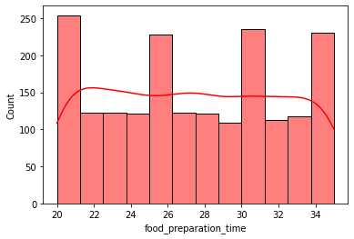

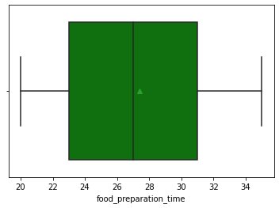

```python
# Observation of food preparation time
sns.histplot(data=df,x='food_preparation_time',bins='fd', kde= True,color='red')
plt.show()
sns.boxplot(data=df,x='food_preparation_time', color ='green',showmeans=True)
plt.show()
```

• The minimum food preparation time is 20 minutes, while the maximum is 35 minutes and the mean is 27 minutes.

• The boxplot shows that there are no outliers in this column.

**2. Observation of delivery time**

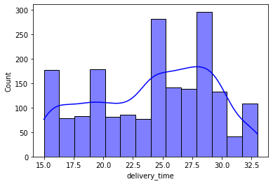

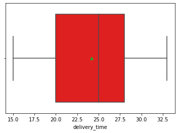

```python
# Observation of delivery time
sns.histplot(data=df,x='delivery_time',bins='auto', kde= True,color='blue')
plt.show()
sns.boxplot(data=df,x='delivery_time', color='red',showmeans=True)
plt.show()
```

Note about: **Customer Id & Order Id** It is critical to note that Customer Id and Order Id are typically considered as unique identifiers or codes assigned to customers and orders, respectively. These identifiers are generally represented as numerical data, but they do not have any inherent numerical value or meaning in terms of the analysis of the data. Therefore, they are usually treated as nominal or categorical variables rather than numerical variables in statistical analysis. In other words, they are treated as labels or categories rather than quantitative data that can be added, subtracted, or analyzed using arithmetic operations.

**3.Observation of Customer Id**

```python
# Number of unique customer ids
number_of_unique_customer_id = df['customer_id'].nunique()
print(number_of_unique_customer_id)
```

```
1200
```

There are 1200 unique customer ids. That means that customer ids maybe repeated in the dataset indicating that each customer has an unique id and that id could be used to provide discounts etc.

**4.Observation of Order Id**

```python
#Number of Unique Order Ids
unique_order_id = df['order_id'].nunique()
print(unique_order_id)
```

```
1898
```

Unlike customer ids order id is unique for the entire dataset and there are no reptitions.

This enables us to ensure that there are no data entry errors with regards to Order id column.

**5.Observation of Cost of the order**

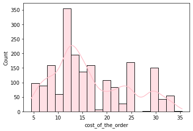

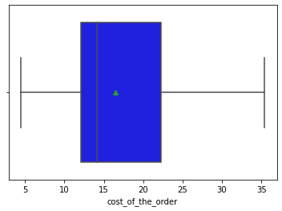

```python
# Analysis food preparation time
sns.histplot(data=df,x='cost_of_the_order',bins='auto', kde= True,color= 'pink')
plt.show()
sns.boxplot(data=df,x='cost_of_the_order', color = 'blue',showmeans=True)
plt.show()
```

1. Maximum cost of the order is 35.41, Mean is 16.49 and Minimum is 4.47.
2. There may be a slight right skew(positive) indicating most of the orders cost closer to the mean than towards the maximum. 75% of the values are within 22.30.

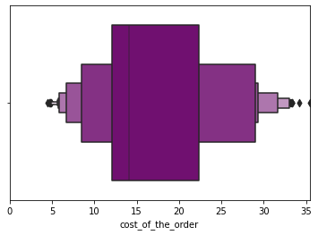

```python
# create the boxen plot for the cost of the orders
sns.boxenplot(data=df, x='cost_of_the_order', color='purple')

# set the x-axis limits to show all the values in the 'cost_of_the_order' column
plt.xlim(0, df['cost_of_the_order'].max())

# display the plot
plt.show()
```

We can further see that most of the prices fall between 12 and 22 dollars.

# **Exploring the categorical variables**

The categorical variables are:

1. restaurant_name
2. cuisine_type
3. day_of_the_week
4. rating

**6.Observation of Restaurants**

```python
# Get the number of unique restaurant names
unique_restaurants = df['restaurant_name'].nunique()

# Print the number of unique restaurant names
print(unique_restaurants)
```

```
178
```

The restaurant names cannot be shown in a visualization like plots. There are 178 restaurant names.

```python
# count the number of restaurants for each cuisine_type
count_by_cuisine = df.groupby('cuisine_type')['restaurant_name'].nunique()

# print the count for each cuisine_type
print(count_by_cuisine)
```

```
cuisine_type
American          41
Chinese           16
French             3
Indian            14
Italian           31
Japanese          29
Korean             5
Mediterranean      5
Mexican           11
Middle Eastern     7
Southern           2
Spanish            3
Thai               9
Vietnamese         3
Name: restaurant_name, dtype: int64
```

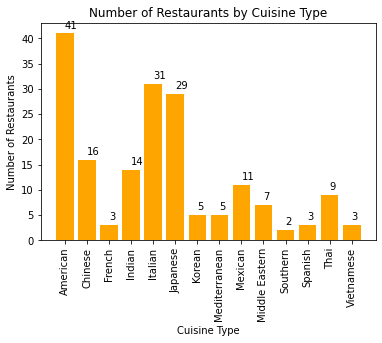

```python
# create a bar graph
plt.bar(count_by_cuisine.index, count_by_cuisine.values, color='orange')

# set the title and axis labels
plt.title('Number of Restaurants by Cuisine Type')
plt.xlabel('Cuisine Type')
plt.ylabel('Number of Restaurants')
plt.xticks(rotation=90)
# add the number of restaurants on each bar
for i, v in enumerate(count_by_cuisine.values):
    plt.text(i, v + 1, str(v))

# display the graph
plt.show()
```

There are 41 American restaurants which is the highest in number. The lowest is Southern (2 restaurants) followed by Spanish, Vietnamese and French that are 3 in number.

**7.Observation of Cuisine types**

```python
#print number of unique cuisine types
print(df['cuisine_type'].nunique())

# Get the unique cuisine types
unique_cuisine = df['cuisine_type'].unique()
# Print the unique cuisine types
print(unique_cuisine)
```

```
14
['Korean' 'Japanese' 'Mexican' 'American' 'Indian' 'Italian'
 'Mediterranean' 'Chinese' 'Middle Eastern' 'Thai' 'Southern' 'French'
 'Spanish' 'Vietnamese']
```

There are 14 different types of cuisine.

They are:

1. 'Korean'
2. 'Japanese'
3. 'Mexican'
4. 'American'
5. 'Indian'
6. 'Italian'
7. 'Mediterranean'
8. 'Chinese'
9. 'Middle Eastern'
10. 'Thai'
11. 'Southern'
12. 'French'
13. 'Spanish'
14. 'Vietnamese'

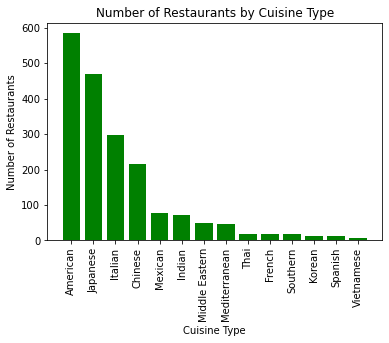

```python
# count the number of restaurants for each cuisine_type
count_by_cuisine = df['cuisine_type'].value_counts()

# create a bar plot
plt.bar(count_by_cuisine.index, count_by_cuisine.values,color='green')

# set the title and axis labels
plt.title('Number of Restaurants by Cuisine Type')
plt.xlabel('Cuisine Type')
plt.ylabel('Number of Restaurants')
plt.xticks(rotation=90)
# display the graph
plt.show()
```

**8.Observation of Day of the week**

```python
# Unique Day of the Week
print(df['day_of_the_week'].unique())
```

```
['Weekend' 'Weekday']
```

The day of the week is categorized into either Weekend or Weekday.

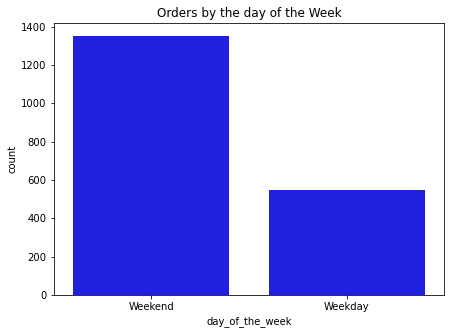

```python
#Bar Graph to show the orders by the day of the week
plt.figure(figsize=(7,5))
sns.countplot(data=df, x='day_of_the_week',color='blue');
plt.title('Orders by the day of the Week');
```

There are more orders in the weekends compared to the weekdays.

**9.Observation of Rating**

```
['Not given' '5' '3' '4']
```

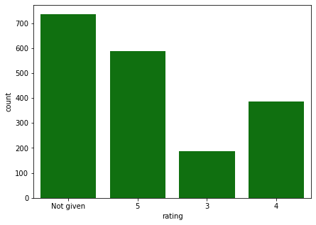

```python
# Unique Ratings
print(df['rating'].unique())

#Bar Graph to show the rating
plt.figure(figsize=(7,5))
sns.countplot(data=df, x='rating',color='green');
```

1. There are 4 unique values in column rating. They are:
2. 'Not given'
3. 5
4. 4
5. 3
6. Among these 'Not given'values are 736. That means there are 736 values not rated.
7. Because there are 736 values are 'Not given'the rating column is of object datatype.
8. Most of the ratings are 5 if the 736 'Not given' values are not taken into consideration.

# **Questions 7 to 11**

### **Question 7**: Which are the top 5 restaurants in terms of the number of orders received? [1 mark]

```python
#the top 5 restaurants in terms of the number of orders received
top_restaurants = df.groupby('restaurant_name').agg({'order_id': 'sum'}).sort_values(by='order_id', ascending=False).head(5)
print(top_restaurants)
```

```
                            order_id
restaurant_name
Shake Shack                323578315
The Meatball Shop          195029322
Blue Ribbon Sushi          175813497
Blue Ribbon Fried Chicken  141840344
Parm                       100476245
```

#### Observations:

The top five restuarants based on number of orders received are:

1. Shake Shack
2. The Meatball Shop
3. Blue Ribbon Sushi
4. Blue Ribbon Fried Chicken
5. Parm

Reference: [Using Groupby](https://sparkbyexamples.com/pandas/pandas-groupby-sort-within-groups/)

### **Question 8**: Which is the most popular cuisine on weekends? [1 mark]

```python
# the most popular cuisine on weekends
# filter the dataframe to include only rows where day_of_the_week is Weekend
weekend_orders = df[df['day_of_the_week'] == 'Weekend']

# group the resulting dataframe by cuisine_type and count the number of rows in each group
cuisine_counts = weekend_orders.groupby('cuisine_type').size()

# sort the resulting series in descending order to find the most popular cuisine
most_popular_cuisine = cuisine_counts.sort_values(ascending=False).index[0]

print("The most popular cuisine on weekends is: {}".format(most_popular_cuisine))
```

```
The most popular cuisine on weekends is: American
```

#### Observations:

The most popular cuisine on the weekends is American.

Reference: [Using Groupby](https://sparkbyexamples.com/pandas/pandas-groupby-sort-within-groups/)

### **Question 9**: What percentage of the orders cost more than 20 dollars? [2 marks]

```python
# percentage of the orders that cost more than 20 dollars
percent_expensive = len(df[df['cost_of_the_order'] > 20]) / len(df) * 100

# formatting string for a float value to display it with two decimal places.
print(f"{percent_expensive:.2f}% of orders cost more than 20 dollars")
```

```
29.24% of orders cost more than 20 dollars
```

#### Observation:

29.24% of orders cost more than 20 dollars

Reference: [Pandas Cheat Sheet](https://www.webpages.uidaho.edu/~stevel/cheatsheets/Pandas%20DataFrame%20Notes_12pages.pdf)

### **Question 10**: What is the mean order delivery time? [1 mark]

```python
#  mean order delivery time
mean_delivery_time = df['delivery_time'].mean()
print("The mean order delivery time is {:.2f} minutes".format(mean_delivery_time))
```

```
The mean order delivery time is 24.16 minutes
```

#### Observations:

The mean order delivery time is 24.16 minutes or 24 minutes and 9.6 seconds

### **Question 11:** The company has decided to give 20% discount vouchers to the top 3 most frequent customers. Find the IDs of these customers and the number of orders they placed. [1 mark]

```python
# Ids of 3 most frequent customers
# count the number of orders per customer using value_counts()
orders_per_customer = df['customer_id'].value_counts()

# get the IDs and order counts of the top 3 customers
top_customers = orders_per_customer.head(3)

print("Top 3 most frequent customers:")
print(top_customers)
```

```
Top 3 most frequent customers:
52832    13
47440    10
83287     9
Name: customer_id, dtype: int64
```

#### Observations:

The top three customers and the number of orders they placed are:

Customer.............. Number of orders

1. 52832........... 13
2. 47440........... 10
3. 83287........... 9

# **Multivariate Analysis**

### **Question 12**: Perform a multivariate analysis to explore relationships between the important variables in the dataset. (It is a good idea to explore relations between numerical variables as well as relations between numerical and categorical variables) [10 marks]

# **Bivariate and Multivariate Analysis**

Variables

• restaurant_name  
• cuisine_type  
• day_of_the_week  
• rating  
• food_preparation_time  
• delivery_time  
• order_id  
• customer_id  
• cost_of_the_order

**1.Correlation among numerical variables**

- Delivery Time
- Food Preparation Time
- Cost of the order

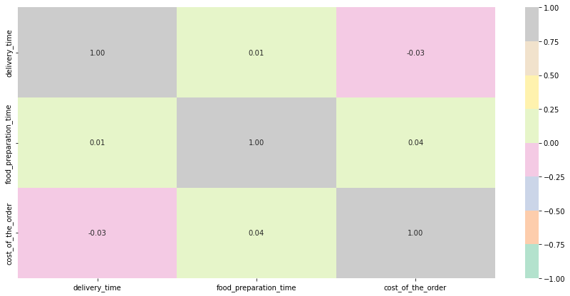

```python
# Check for correlation among numerical variables delivery_time, food_preparation_time and cost_of_the_order
num_var = ['delivery_time','food_preparation_time','cost_of_the_order']

corr = df[num_var].corr()

# plot the heatmap

plt.figure(figsize=(15, 7))
sns.heatmap(corr, annot=True, vmin=-1, vmax=1, fmt=".2f", cmap="Pastel2")
plt.show()
```

Observation

• There is a weak correlation among the three variables- delivery_time, food_preparation_time and cost_of_the_order.

• Delivery time and cost of the order has a weak negative correlation.

• Delivery time and food preparation time has a weak positive correlation.

• Food preparation time and cost of the order has a weak positive correlation.

**2.Cuisine Type Vs Number of Orders**

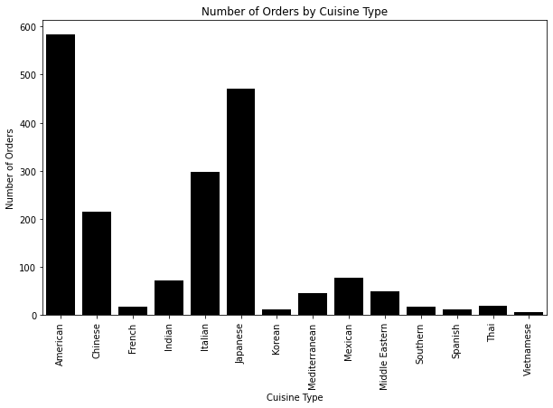

```python
# Group the orders by cuisine type and count the number of orders
orders_by_cuisine = df.groupby('cuisine_type')['order_id'].count()

# Create a bar plot to show the number of orders for each cuisine type
plt.figure(figsize=(10, 6)) # specify figure size
sns.barplot(x=orders_by_cuisine.index, y=orders_by_cuisine.values,color='black')
plt.title('Number of Orders by Cuisine Type')
plt.xlabel('Cuisine Type')
plt.ylabel('Number of Orders')
plt.xticks(rotation=90)
plt.show()
```

The maximum number of orders are American followed by Japanese and Italian.

The least number of orders are of Cuisine Type Vietnamese.

**3.Cuisine Type Vs Restaurant**

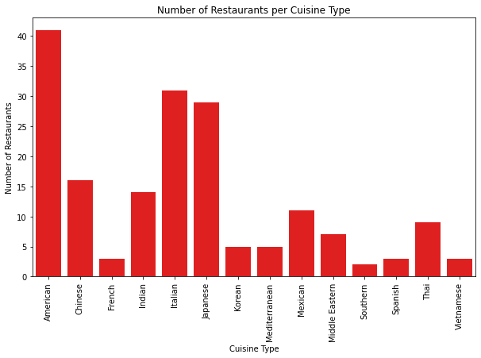

```python
# count the number of restaurants based on cuisine type
cuisine_counts = df.groupby('cuisine_type')['restaurant_name'].nunique().reset_index(name='count')
plt.figure(figsize=(10, 6)) # specify figure size
# plot the bar graph
sns.barplot(x='cuisine_type', y='count', data=cuisine_counts,color='red')
plt.title('Number of Restaurants per Cuisine Type')
plt.xlabel('Cuisine Type')
plt.ylabel('Number of Restaurants')
plt.xticks(rotation=90)
plt.show()
```

The maximum number of restaurants are American followed by Italian and Japanese.

Fewer number of restaurants are Southern, Spanish, French and Vietnamese.

**4.Cuisine Type Vs Restaurant and Order Counts**

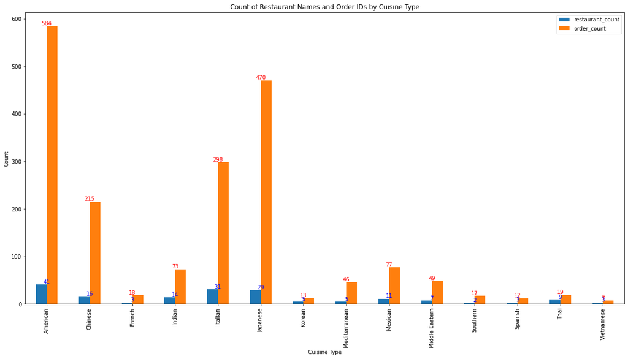

```python
# group the dataframe by cuisine_type and count the unique restaurant names and order ids
restaurant_count = df.groupby('cuisine_type')['restaurant_name'].nunique()
order_count = df.groupby('cuisine_type')['order_id'].nunique()

# combine the two series into a single dataframe
result_df = pd.concat([restaurant_count, order_count], axis=1)
result_df.columns = ['restaurant_count', 'order_count']
# create a bar plot to visualize the results
ax = result_df.plot(kind='bar', rot=90,figsize=(20, 10))
# add labels to the plot
ax.set_xlabel('Cuisine Type')
ax.set_ylabel('Count')
ax.set_title('Count of Restaurant Names and Order IDs by Cuisine Type');

for i, v in enumerate(result_df.values):
    ax.text(i, v[0]+2, str(v[0]), color='blue', ha='center')
    ax.text(i, v[1]+2, str(v[1]), color='red', ha='center')
```

• This grouped bar plot shows us the restaurant counts and order counts based on cuisine type.

• The maximum number of restaurants and orders are of cuisine type American.

• Although the number of Japanese restaurants is fewer compared to Italian, they have more orders than Italian.

• The least number of orders are Vietnamese.

**5.Income generated by Cuisine Type**

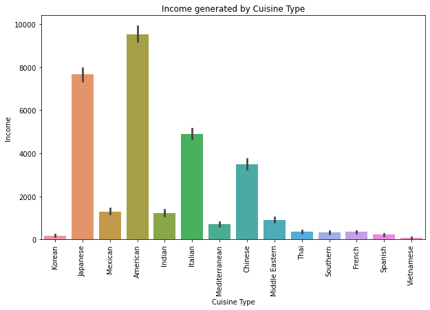

```python
plt.figure(figsize=(10,6)) # set figure size
sns.barplot(x='cuisine_type', y='cost_of_the_order', data=df, estimator=sum) # plot bar graph
plt.xticks(rotation=90) # rotate x-axis labels by 90 degrees
plt.title('Income generated by Cuisine Type')
plt.xlabel('Cuisine Type')
plt.ylabel('Income')
plt.show()
```

The maximum income is generated by American cuisine, followed by Japanese, Italian and Chinese.

**6.Income Generated by Day of the Week**

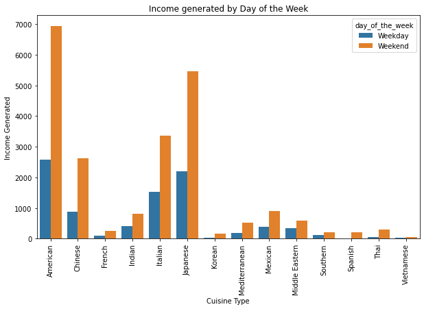

```python
plt.figure(figsize=(10, 6))  # specify figure size

# calculate the sum of cost_of_the_order based on cuisine_type and day_of_the_week
grouped = df.groupby(['cuisine_type', 'day_of_the_week'])['cost_of_the_order'].sum().reset_index()

# plot the bar graph
sns.barplot(x='cuisine_type', y='cost_of_the_order', hue='day_of_the_week', data=grouped)
plt.xticks(rotation=90)
plt.title('Income generated by Day of the Week')
plt.xlabel('Cuisine Type')
plt.ylabel('Income Generated')
plt.show()
```

We can see that more income is generated during the weekends for all cuisine types and that American cuisine generates more income during weekdays and weekends.

**7.Delivery Time vs. Cuisine Type based on the Day of the Week**

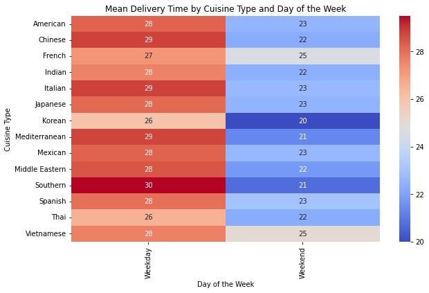

```python
plt.figure(figsize=(10, 6))

# create a pivot table to calculate the mean delivery time by cuisine type and day of the week
pivot_df = df.pivot_table(index='cuisine_type', columns='day_of_the_week', values='delivery_time', aggfunc='mean')

# plot the heatmap
sns.heatmap(pivot_df, annot=True, cmap='coolwarm')

# set the plot title and axis labels
plt.title('Mean Delivery Time by Cuisine Type and Day of the Week')
plt.xlabel('Day of the Week')
plt.ylabel('Cuisine Type')

# rotate the x-axis labels
plt.xticks(rotation=90)

plt.show()
```

In general the Weekday delivery times take longer than Weekend delivery times. On weekdays it takes longer to deliver Southern food and on weekends it takes longer to deliver French and Vietnamese food. Korean food takes shorter time to be delivered on weekends.

Reference: [Pandas Pivot Table](https://sparkbyexamples.com/pandas/pandas-pivot-table-explained-with-examples/)

**8.Food Preparation Time vs. Cuisine Type based on the Day of the Week**

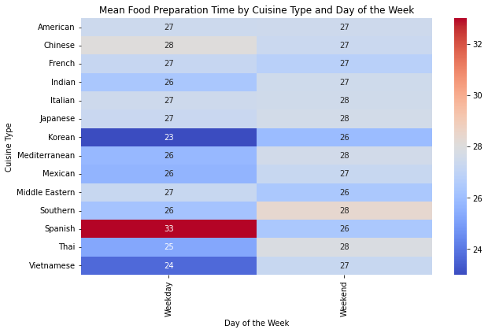

```python
plt.figure(figsize=(10, 6))

# create a pivot table to calculate the mean food preparation time by cuisine type and day of the week
pivot_df = df.pivot_table(index='cuisine_type', columns='day_of_the_week', values='food_preparation_time', aggfunc='mean')

# plot the heatmap
sns.heatmap(pivot_df, annot=True, cmap='coolwarm')

# set the plot title and axis labels
plt.title('Mean Food Preparation Time by Cuisine Type and Day of the Week')
plt.xlabel('Day of the Week')
plt.ylabel('Cuisine Type')

# rotate the x-axis labels
plt.xticks(rotation=90)

plt.show()
```

Most cuisine types almost take similar time to prepare during the weekends and weekdays. The exception is Spanish food that takes longer to prepare on weekdays compared to all other foods. Korean food takes shorter time to prepare on the weekdays.

Reference: Pandas [Pivot Table](https://sparkbyexamples.com/pandas/pandas-pivot-table-explained-with-examples/)

**9.Delivery Time vs. Rating**

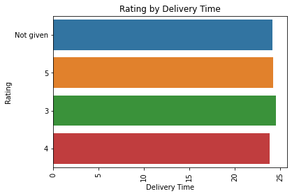

```python
# create a bar plot
sns.barplot(x='delivery_time', y='rating', data=df, ci=None);

# set the title and labels
plt.title('Rating by Delivery Time')
plt.xlabel('Delivery Time')
plt.ylabel('Rating')

# rotate the x-axis labels by 90 degrees
plt.xticks(rotation=90);

# set the figure size
plt.figure(figsize=(10, 6));

# display the plot
plt.show()
```

We can see that Rating is not really affected by Delivery time.

**10.Food Preparation Time vs. Rating**

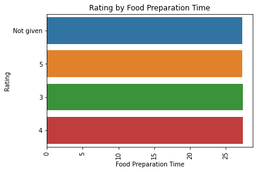

```python
# create a bar plot
sns.barplot(x='food_preparation_time', y='rating', data=df, ci=None);

# set the title and labels
plt.title('Rating by Food Preparation Time')
plt.xlabel('Food Preparation Time')
plt.ylabel('Rating')

# rotate the x-axis labels by 90 degrees
plt.xticks(rotation=90);

# set the figure size
plt.figure(figsize=(10, 6));

# display the plot
plt.show()
```

Again Food preparation time does not affect rating. This could be because rating is non-numeric and there are 736 rows that have no rating given.

**11.Order to delivery time Vs. Cuisine Type**

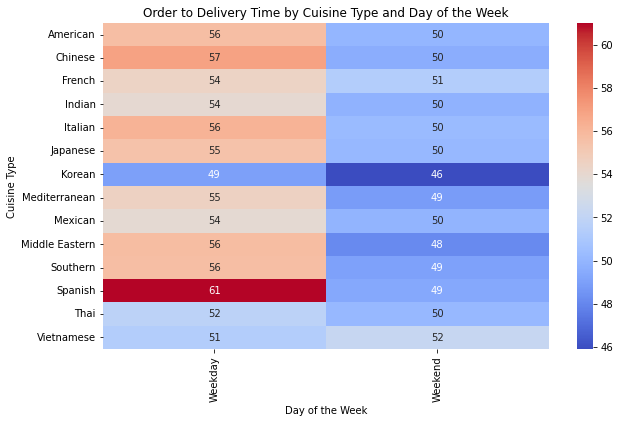

```python
# calculate total time taken for each order
df['total_delivery_time'] = df['food_preparation_time'] + df['delivery_time']

plt.figure(figsize=(10, 6))

# create a pivot table to calculate the mean food preparation time by cuisine type and day of the week
pivot_df = df.pivot_table(index='cuisine_type', columns='day_of_the_week', values='total_delivery_time', aggfunc='mean')

# plot the heatmap
sns.heatmap(pivot_df, annot=True, cmap='coolwarm')

# set the plot title and axis labels
plt.title('Order to Delivery Time by Cuisine Type and Day of the Week')
plt.xlabel('Day of the Week')
plt.ylabel('Cuisine Type')

# rotate the x-axis labels
plt.xticks(rotation=90)

plt.show()
```

Order to delivery time is longer during the week than on the weekends. Spanish cuisine takes longer than 60 minutes on weekdays while Korean food takes shortest time during weekdays and weekends.

Reference: [Pandas Pivot Table](https://sparkbyexamples.com/pandas/pandas-pivot-table-explained-with-examples/)

# **Questions 13-17**

### **Question 13:** The company wants to provide a promotional offer in the advertisement of the restaurants. The condition to get the offer is that the restaurants must have a rating count of more than 50 and the average rating should be greater than 4. Find the restaurants fulfilling the criteria to get the promotional offer. [3 marks]

As the rating column was an object and not an integer, I thought about replacing the 'Not given' values with 0.

```python
# Create a new dataframe where 'Not given' values are replaced with zero
new_df = df.replace('Not given', 0)
# Create a new column 'rating_count' based on the counts of unique values in the 'rating' column
new_df['rating_count'] = new_df['rating'].map(new_df['rating'].value_counts())

# Convert the 'rating' column to numeric
new_df['rating'] = pd.to_numeric(new_df['rating'])
new_df.info()
```

```
<class 'pandas.core.frame.DataFrame'>
RangeIndex: 1898 entries, 0 to 1897
Data columns (total 11 columns):
 #   Column                 Non-Null Count  Dtype
---  ------                 --------------  -----
 0   order_id               1898 non-null   int64
 1   customer_id            1898 non-null   int64
 2   restaurant_name        1898 non-null   object
 3   cuisine_type           1898 non-null   object
 4   cost_of_the_order      1898 non-null   float64
 5   day_of_the_week        1898 non-null   object
 6   rating                 1898 non-null   int64
 7   food_preparation_time  1898 non-null   int64
 8   delivery_time          1898 non-null   int64
 9   total_delivery_time    1898 non-null   int64
 10  rating_count           1898 non-null   int64
dtypes: float64(1), int64(7), object(3)
memory usage: 163.2+ KB
```

**PLEASE NOTE:**

1. Changing the 'rating' column to numeric does not solve our problem. The zero values will be calculated in the averages and hence none of the restaurants will be eligible for the promotional offer.
2. The solution will be to create another dataframe with rows with‘0’ or not given values dropped from the dataset.

```python
# Create a new dataframe without rows where the 'rating' column has a value of 0
newer_df = new_df.loc[new_df['rating'] != 0].copy()
newer_df.info()
```

```
<class 'pandas.core.frame.DataFrame'>
Int64Index: 1162 entries, 2 to 1896
Data columns (total 11 columns):
 #   Column                 Non-Null Count  Dtype
---  ------                 --------------  -----
 0   order_id               1162 non-null   int64
 1   customer_id            1162 non-null   int64
 2   restaurant_name        1162 non-null   object
 3   cuisine_type           1162 non-null   object
 4   cost_of_the_order      1162 non-null   float64
 5   day_of_the_week        1162 non-null   object
 6   rating                 1162 non-null   int64
 7   food_preparation_time  1162 non-null   int64
 8   delivery_time          1162 non-null   int64
 9   total_delivery_time    1162 non-null   int64
 10  rating_count           1162 non-null   int64
dtypes: float64(1), int64(7), object(3)
memory usage: 108.9+ KB
```

```python
eligible_restaurants = newer_df.groupby('restaurant_name').filter(lambda x: x['rating'].count() > 50 and x['rating'].mean() > 4)
result = eligible_restaurants['restaurant_name'].unique()

print("Restaurants eligible for promotional offer:")
print(result)
```

```
Restaurants eligible for promotional offer:
['Blue Ribbon Fried Chicken' 'Shake Shack' 'Blue Ribbon Sushi'
 'The Meatball Shop']
```

#### Observations:

1. Changing the 'rating' column to numeric does not solve our problem. The zero values will be calculated in the averages and hence none of the restaurants will be eligible for the promotional offer.
2. The solution will be to create another dataframe with rows with‘0’values dropped from the dataset.
3. A new dataset was created with rows that had ‘not given’ rating dropped.
4. This code creates a new DataFrame called "eligible_restaurants" by grouping the "newer_df" DataFrame by "restaurant_name" and filtering out any groups where the count of ratings in the "rating" column is less than or equal to 50, or the mean of the ratings in the "rating" column is less than or equal to 4. Then, it extracts the unique restaurant names from the "restaurant_name" column of the "eligible_restaurants" DataFrame and saves it to a variable called "result". Finally, it prints out the unique restaurant names that meet the criteria for being eligible for a promotional offer.
5. Restaurants eligible for promotional offer are:

• Blue Ribbon Fried Chicken

• Shake Shack

• Blue Ribbon Sushi

• The Meatball Shop

### **Question 14:** The company charges the restaurant 25% on the orders having cost greater than 20 dollars and 15% on the orders having cost greater than 5 dollars. Find the net revenue generated by the company across all orders. [3 marks]

```python
# define a function to calculate the revenue generated by the company for each order
def calculate_revenue(cost):
    if cost > 20:
        return cost * 0.75
    elif cost > 5:
        return cost * 0.85
    else:
        return cost

# apply the function to the cost_of_the_order column and sum up the results
net_revenue = df['cost_of_the_order'].apply(calculate_revenue).sum()

print('Net revenue generated by the company: ${:.2f}'.format(net_revenue))
```

```
Net revenue generated by the company: $25148.52
```

#### Observations:

After defining the function, the code applies the function to each value in the "cost_of_the_order" column of a DataFrame called "df". It then sums up the results of the function application to get the net revenue generated by the company.

Finally, the code prints out the net revenue generated by the company in a formatted string with two decimal places.

### **Question 15:** The company wants to analyze the total time required to deliver the food. What percentage of orders take more than 60 minutes to get delivered from the time the order is placed? (The food has to be prepared and then delivered.) [2 marks]

```python
# calculate total time taken for each order
df['total_delivery_time'] = df['food_preparation_time'] + df['delivery_time']

# filter orders that take more than 60 minutes
long_delivery_orders = df[df['total_delivery_time'] > 60]['order_id'].nunique()

# calculate percentage of orders that take more than 60 minutes
total_orders = df['order_id'].nunique()
percent_long_delivery = (long_delivery_orders / total_orders) * 100

# print the percentage
print(f"{percent_long_delivery:.2f}% of orders take more than 60 minutes to get delivered.")
```

```
10.54% of orders take more than 60 minutes to get delivered.
```

#### Observations:

**10.54% of the orders take more than 60 minutes to get delivered.**

We saw in the multivariate analysis that Spanish cuisine takes longer than 60 minutes on weekdays while Korean food takes shortest time during weekdays and weekends.

### **Question 16:** The company wants to analyze the delivery time of the orders on weekdays and weekends. How does the mean delivery time vary during weekdays and weekends? [2 marks]

```python
# group the data by day_of_the_week and calculate the mean of delivery_time
delivery_time_by_day = df.groupby('day_of_the_week')['delivery_time'].mean()
print(delivery_time_by_day)
```

```
day_of_the_week
Weekday   28.34
Weekend   22.47
Name: delivery_time, dtype: float64
```

#### Observations:

Weekday 28.34 minutes to deliver food

Weekend 22.47 minutes to deliver food

In general the Weekday delivery times take longer than Weekend delivery times. It takes about 5 minutes longer to deliver on the weekdays than on the weekends.

Earlier we saw that on weekdays it takes longer to deliver Southern food and on weekends it takes longer to deliver French and Vietnamese food. Korean food takes shorter time to be delivered on weekends.

### Conclusion and Recommendations

### **Question 17:** What are your conclusions from the analysis? What recommendations would you like to share to help improve the business? (You can use cuisine type and feedback ratings to drive your business recommendations.) [6 marks]

### Conclusions:

**A summary of the results**:

• Dataset includes 178 restaurants serving 14 different types of cuisines.

• More orders are placed during weekends compared to weekdays.

• Minimum food preparation time is 20 minutes, maximum is 35 minutes, and mean is 27 minutes. No outliers found.

• Minimum delivery time is 15 minutes, mean is 24 minutes, and maximum is 33 minutes.

• There are 1200 unique customer IDs and order IDs are unique for the entire dataset.

• Maximum cost of an order is $35.41, mean is $16.49, and minimum is $4.47.

• Weak correlations are observed among delivery time, food preparation time, and cost of the order.

• More income is generated during weekends for all cuisine types and American cuisine generates more income during both weekdays and weekends.

• Weekday delivery times take longer than weekend delivery times in general. • Rating is not affected by delivery or food preparation time, and 736 rows have no rating given.

• Blue Ribbon Fried Chicken, Shake Shack, Blue Ribbon Sushi, and The Meatball Shop are eligible for promotional offers.

• 10.54% of orders take more than 60 minutes to be delivered.

• Spanish cuisine takes longer than 60 minutes on weekdays, while Korean food takes the shortest time during weekdays and weekends.

**Conclusion**

• Based on the information provided, the restaurants and food business in this location seem to be diverse in terms of cuisine types offered. American, Japanese, and Italian are the most popular cuisine types, while Vietnamese, Spanish, and French have fewer orders and restaurants.

• The average food preparation time is 27 minutes, which seems reasonable for most customers. The maximum delivery time is 33 minutes, which is within a reasonable timeframe as well. However, 10.54% of the orders take more than 60 minutes to get delivered, which could be a cause for concern.

• The average cost of an order is 16.49 dollars, with a maximum of $35.41. This suggests that the customers are willing to pay higher prices for quality food and service. It is also worth noting that the rating is not affected by delivery or preparation time, which suggests that customers prioritize quality over speed.

In conclusion, the restaurants and food business in this location seem to be diverse and popular among the locals. While there are some areas of concern such as longer delivery times for certain cuisine types, the overall business appears to be profitable and sustainable. We may need more information to conclusively state the profit or loss of business here.

### Recommendations:

Based on the analysis results, it appears that a large portion of the dataset (736 rows) have no rating given. To improve **customer response to ratings**, the following recommendations can be considered:

• Encourage customers to leave ratings by offering incentives such as discounts or loyalty points.

• Make the rating process as simple and user-friendly as possible, with clear instructions and an easy-to-use interface. Example: Likert Scale, Comment Cards.

• Provide customers with more information about the rating system, such as how ratings are used and the benefits of leaving feedback.

• Follow up with customers who have placed orders but have not left a rating, perhaps by sending a reminder email or message asking for their feedback.

• Ensure that the delivery and food preparation times are consistent and accurate, as these factors may influence a customer's decision to leave a rating.

• Take customer feedback seriously and use it to improve the overall quality of the service provided. This can help to build trust and loyalty among customers, which may in turn encourage them to leave ratings in the future.

Based on the analysis, here are some recommendations to **improve orders for cuisine types other than American**:

• **Offer promotions and discounts for other cuisine types**: As American cuisine has the highest number of orders and restaurants; it might be beneficial to offer promotions and discounts for other cuisine types to encourage customers to try different types of food.

• **Improve marketing for other cuisine types**: The data analysis shows that the number of orders for other cuisine types is lower than that of American cuisine. Therefore, it might be useful to invest in marketing campaigns that promote other cuisine types, such as Japanese, Italian, and Vietnamese, to increase awareness and attract more customers.

• **Expand the menu for other cuisine types**: Offering more variety in the menu for other cuisine types might attract customers who are looking for a wider range of options. It can also encourage repeat orders from customers who enjoy the variety.

• **Improve delivery and food preparation times**: Since the delivery time and food preparation time can affect customer satisfaction, it is important to improve the efficiency of these processes for all cuisine types. This can be achieved through better logistics and training of staff. Restaurants can optimize the delivery process by using efficient routes, tracking delivery vehicles, and using real-time traffic information. This can help reduce the delivery time and improve customer satisfaction.

• **Collect feedback and ratings for other cuisine types**: Encouraging customers to provide feedback and ratings for other cuisine types can help identify areas for improvement and understand customer preferences. This information can then be used to make changes to the menu, improve the quality of food, and enhance the overall customer experience.